# Heart Disease

##### Author Name: Catherin Pullan

##### Email: catherin.pullan@msea.christuniversity.in

##### Introduction

This notebook aims at using the heart disease dataset to illustrate:

1. Perform Statistical Data Analysis on the Dataset
2. Feature Scaling
3. Perform Exploratory Data Analysis
4. Prepare dataset for modelling
5. compare the models for better prediction

##### Objectives

1. To perform Exploratory Data Analysis
2. To predict for existence of heart disease
3. To standardise the dataset
4. To compare among the models and figure the best model for heart disease prediction

##### Problem Statement

Heart diseases, often known as cardiovascular disease, is the umbrella term for a number of disorders affecting the heart, such as blood vessel diseases like coronary artery disease. The World Health Organisation (WHO) reports that 17.9 million individuals worldwide pass away from heart disease each year. According to medical study, lifestyle decisions play a major role in this heart problem. Furthermore, a number of important variables function as markers, indicating whether or not a person is susceptible to heart disease.

##### About the Dataset

Cleveland, Hungary, Switzerland, and Long Beach V are the four databases that make up this 1988 dataset. It consists of 76 features in total, including the expected feature, although all reported studies use only 14 of these features. The "target" category shows if the person has heart disease; a number of 0 indicates no disease, while a number of 1 indicates the presence of disease.

##### Refrences

1. https://scikit-learn.org/stable/modules/linear_model.html#logistic-regression
2. https://scikit-learn.org/stable/modules/svm.html
3. https://scikit-learn.org/stable/supervised_learning.html

##### Importing the required libraries

```python
import pandas as pd
import numpy as np
import seaborn as sns
```

```python
df = pd.read_csv("heart.csv")
df
```

|  | age | sex | cp | trestbps | chol | fbs | restecg | thalach | exang | oldpeak | slope | ca | thal | target |
| --- | --- | --- | --- | --- | --- | --- | --- | --- | --- | --- | --- | --- | --- | --- |
| 0 | 52 | 1 | 0 | 125 | 212 | 0 | 1 | 168 | 0 | 1.0 | 2 | 2 | 3 | 0 |
| 1 | 53 | 1 | 0 | 140 | 203 | 1 | 0 | 155 | 1 | 3.1 | 0 | 0 | 3 | 0 |
| 2 | 70 | 1 | 0 | 145 | 174 | 0 | 1 | 125 | 1 | 2.6 | 0 | 0 | 3 | 0 |
| 3 | 61 | 1 | 0 | 148 | 203 | 0 | 1 | 161 | 0 | 0.0 | 2 | 1 | 3 | 0 |
| 4 | 62 | 0 | 0 | 138 | 294 | 1 | 1 | 106 | 0 | 1.9 | 1 | 3 | 2 | 0 |
| ... | ... | ... | ... | ... | ... | ... | ... | ... | ... | ... | ... | ... | ... | ... |
| 1020 | 59 | 1 | 1 | 140 | 221 | 0 | 1 | 164 | 1 | 0.0 | 2 | 0 | 2 | 1 |
| 1021 | 60 | 1 | 0 | 125 | 258 | 0 | 0 | 141 | 1 | 2.8 | 1 | 1 | 3 | 0 |
| 1022 | 47 | 1 | 0 | 110 | 275 | 0 | 0 | 118 | 1 | 1.0 | 1 | 1 | 2 | 0 |
| 1023 | 50 | 0 | 0 | 110 | 254 | 0 | 0 | 159 | 0 | 0.0 | 2 | 0 | 2 | 1 |
| 1024 | 54 | 1 | 0 | 120 | 188 | 0 | 1 | 113 | 0 | 1.4 | 1 | 1 | 3 | 0 |

1025 rows × 14 columns

```python
df.head()
```

|  | age | sex | cp | trestbps | chol | fbs | restecg | thalach | exang | oldpeak | slope | ca | thal | target |
| --- | --- | --- | --- | --- | --- | --- | --- | --- | --- | --- | --- | --- | --- | --- |
| 0 | 52 | 1 | 0 | 125 | 212 | 0 | 1 | 168 | 0 | 1.0 | 2 | 2 | 3 | 0 |
| 1 | 53 | 1 | 0 | 140 | 203 | 1 | 0 | 155 | 1 | 3.1 | 0 | 0 | 3 | 0 |
| 2 | 70 | 1 | 0 | 145 | 174 | 0 | 1 | 125 | 1 | 2.6 | 0 | 0 | 3 | 0 |
| 3 | 61 | 1 | 0 | 148 | 203 | 0 | 1 | 161 | 0 | 0.0 | 2 | 1 | 3 | 0 |
| 4 | 62 | 0 | 0 | 138 | 294 | 1 | 1 | 106 | 0 | 1.9 | 1 | 3 | 2 | 0 |

```python
df.tail()
```

|  | age | sex | cp | trestbps | chol | fbs | restecg | thalach | exang | oldpeak | slope | ca | thal | target |
| --- | --- | --- | --- | --- | --- | --- | --- | --- | --- | --- | --- | --- | --- | --- |
| 1020 | 59 | 1 | 1 | 140 | 221 | 0 | 1 | 164 | 1 | 0.0 | 2 | 0 | 2 | 1 |
| 1021 | 60 | 1 | 0 | 125 | 258 | 0 | 0 | 141 | 1 | 2.8 | 1 | 1 | 3 | 0 |
| 1022 | 47 | 1 | 0 | 110 | 275 | 0 | 0 | 118 | 1 | 1.0 | 1 | 1 | 2 | 0 |
| 1023 | 50 | 0 | 0 | 110 | 254 | 0 | 0 | 159 | 0 | 0.0 | 2 | 0 | 2 | 1 |
| 1024 | 54 | 1 | 0 | 120 | 188 | 0 | 1 | 113 | 0 | 1.4 | 1 | 1 | 3 | 0 |

```python
df.describe()
```

|  | age | sex | cp | trestbps | chol | fbs | restecg | thalach | exang | oldpeak | slope | ca | thal | target |
| --- | --- | --- | --- | --- | --- | --- | --- | --- | --- | --- | --- | --- | --- | --- |
| count | 1025.000000 | 1025.000000 | 1025.000000 | 1025.000000 | 1025.00000 | 1025.000000 | 1025.000000 | 1025.000000 | 1025.000000 | 1025.000000 | 1025.000000 | 1025.000000 | 1025.000000 | 1025.000000 |
| mean | 54.434146 | 0.695610 | 0.942439 | 131.611707 | 246.00000 | 0.149268 | 0.529756 | 149.114146 | 0.336585 | 1.071512 | 1.385366 | 0.754146 | 2.323902 | 0.513171 |
| std | 9.072290 | 0.460373 | 1.029641 | 17.516718 | 51.59251 | 0.356527 | 0.527878 | 23.005724 | 0.472772 | 1.175053 | 0.617755 | 1.030798 | 0.620660 | 0.500070 |
| min | 29.000000 | 0.000000 | 0.000000 | 94.000000 | 126.00000 | 0.000000 | 0.000000 | 71.000000 | 0.000000 | 0.000000 | 0.000000 | 0.000000 | 0.000000 | 0.000000 |
| 25% | 48.000000 | 0.000000 | 0.000000 | 120.000000 | 211.00000 | 0.000000 | 0.000000 | 132.000000 | 0.000000 | 0.000000 | 1.000000 | 0.000000 | 2.000000 | 0.000000 |
| 50% | 56.000000 | 1.000000 | 1.000000 | 130.000000 | 240.00000 | 0.000000 | 1.000000 | 152.000000 | 0.000000 | 0.800000 | 1.000000 | 0.000000 | 2.000000 | 1.000000 |
| 75% | 61.000000 | 1.000000 | 2.000000 | 140.000000 | 275.00000 | 0.000000 | 1.000000 | 166.000000 | 1.000000 | 1.800000 | 2.000000 | 1.000000 | 3.000000 | 1.000000 |
| max | 77.000000 | 1.000000 | 3.000000 | 200.000000 | 564.00000 | 1.000000 | 2.000000 | 202.000000 | 1.000000 | 6.200000 | 2.000000 | 4.000000 | 3.000000 | 1.000000 |

```python
df.isnull().sum()
```

```
age         0
sex         0
cp          0
trestbps    0
chol        0
fbs         0
restecg     0
thalach     0
exang       0
oldpeak     0
slope       0
ca          0
thal        0
target      0
dtype: int64
```

```python
df.dtypes
```

```
age           int64
sex           int64
cp            int64
trestbps      int64
chol          int64
fbs           int64
restecg       int64
thalach       int64
exang         int64
oldpeak     float64
slope         int64
ca            int64
thal          int64
target        int64
dtype: object
```

##### Exploratory Data Analysis

```python
import matplotlib.pyplot as plt
```

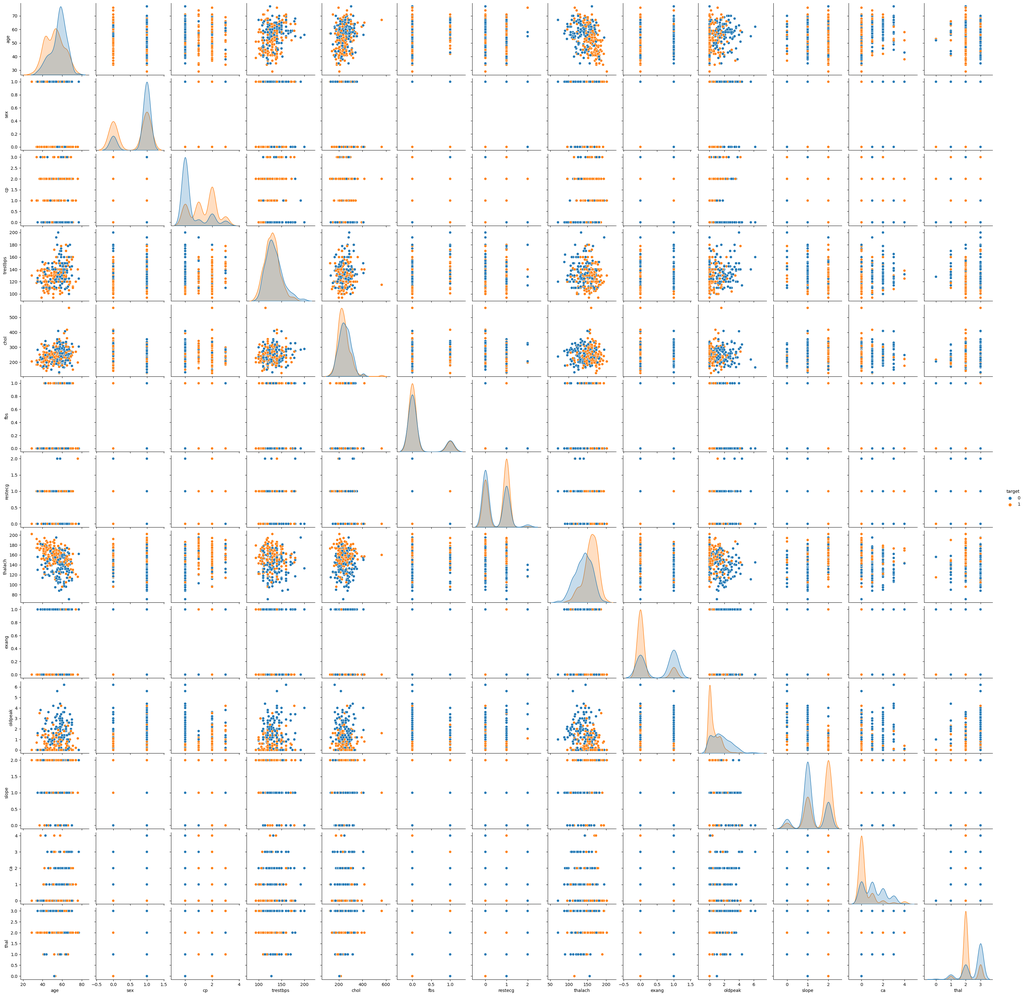

```python
sns.pairplot(df,hue = 'target')
plt.show()
```

###### Correlation matrix heatmap

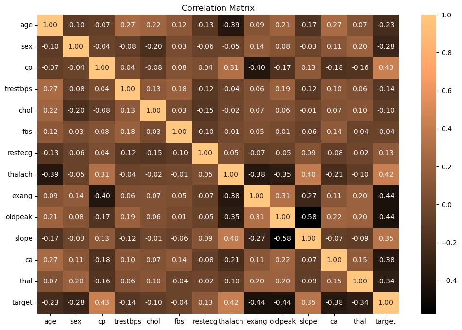

```python
correlation_matrix = df.corr()
plt.figure(figsize = (12,8))
sns.heatmap(correlation_matrix,annot = True, cmap = 'copper', fmt = '.2f')
plt.title('Correlation Matrix')
plt.show()
```

##### Countplot for categorical columns

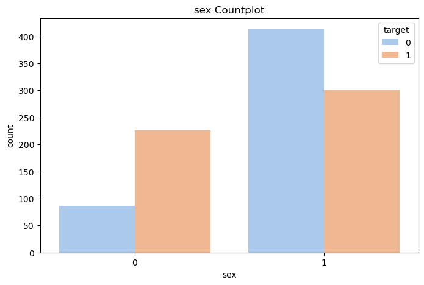

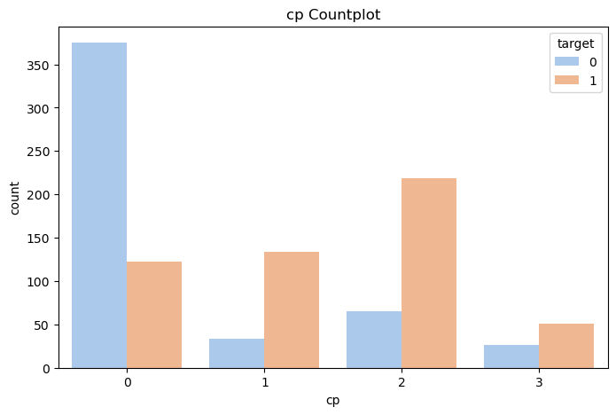

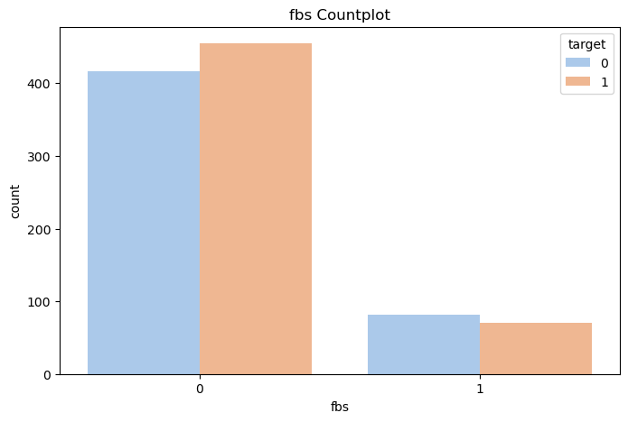

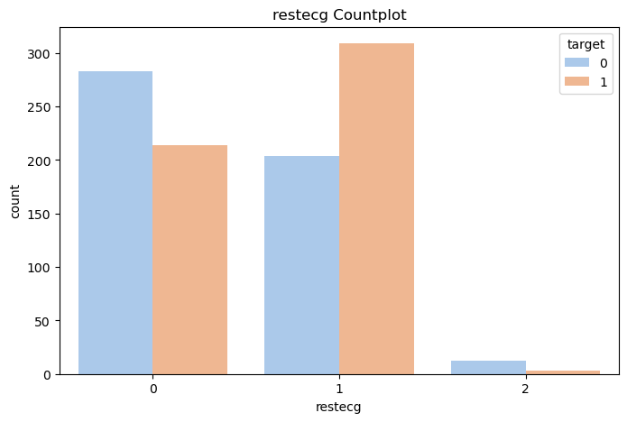

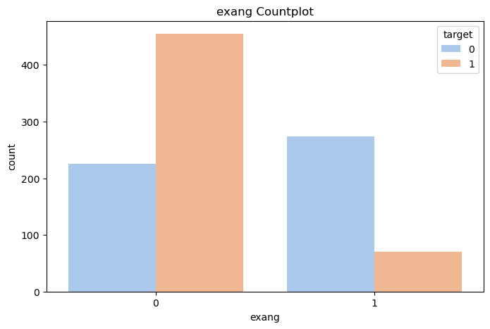

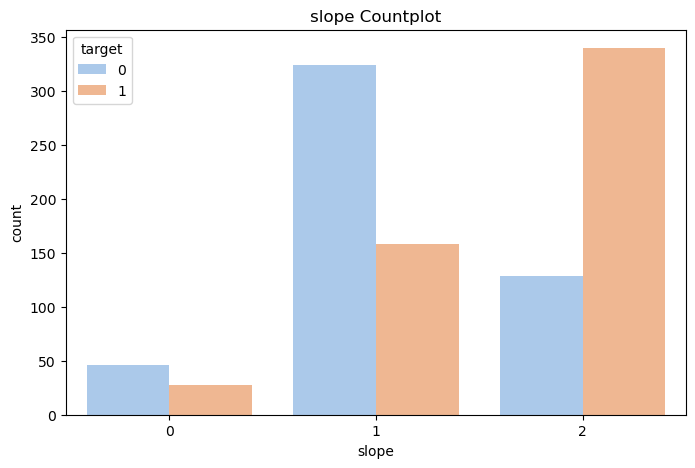

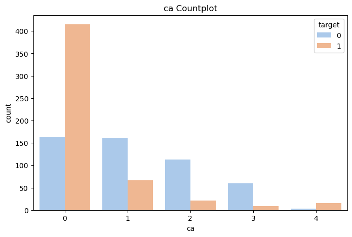

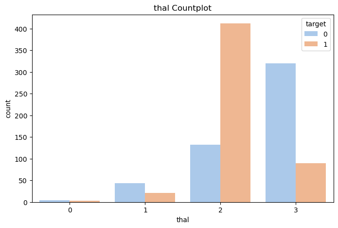

```python
categorical_columns = ['sex', 'cp', 'fbs', 'restecg', 'exang', 'slope', 'ca', 'thal']
for column in categorical_columns:
    plt.figure(figsize=(8, 5))
    sns.countplot(x=column, data=df, hue='target', palette='pastel')
    plt.title(f'{column} Countplot')
    plt.show()
```

###### Boxplot for numerical columns

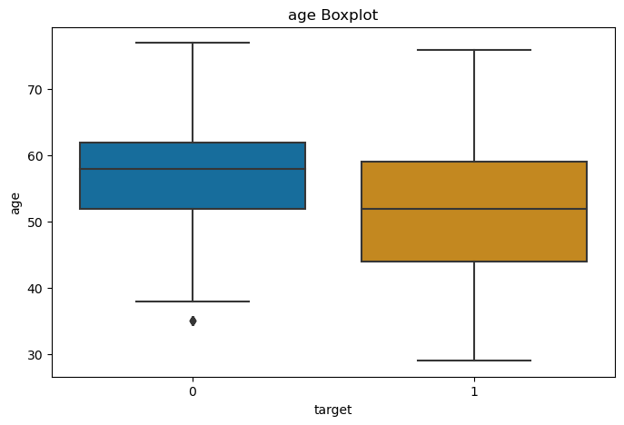

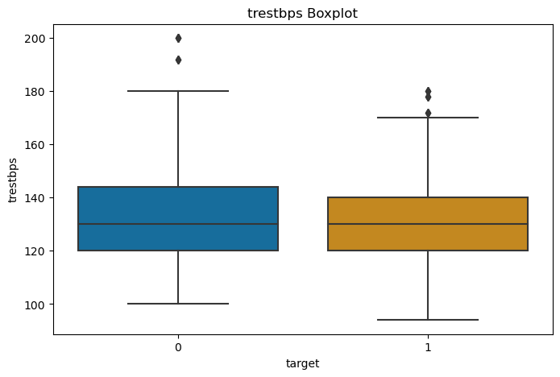

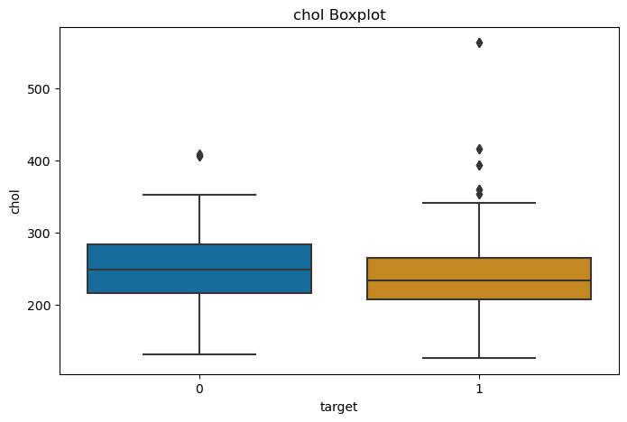

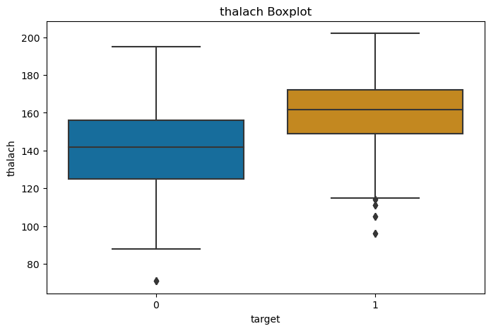

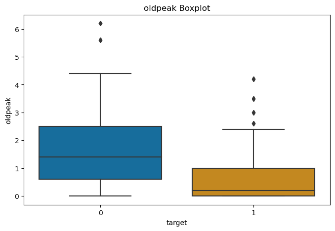

```python
numerical_columns = ['age', 'trestbps', 'chol', 'thalach', 'oldpeak']
for column in numerical_columns:
    plt.figure(figsize=(8, 5))
    sns.boxplot(x='target', y=column, data=df, palette='colorblind')
    plt.title(f'{column} Boxplot')
    plt.show()
```

###### Distribution of the target variable

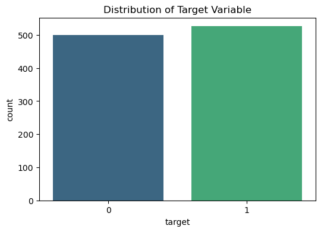

```python
plt.figure(figsize=(6, 4))
sns.countplot(x='target', data=df, palette='viridis')
plt.title('Distribution of Target Variable')
plt.show()
```

##### Age distribution

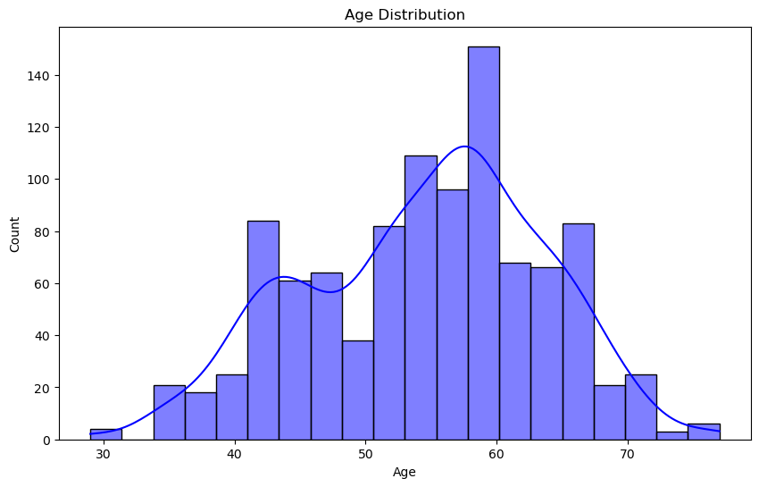

```python
plt.figure(figsize = (10,6))
sns.histplot(df['age'],bins=20, kde = True, color = 'blue')
plt.title('Age Distribution')
plt.xlabel('Age')
plt.show()
```

###### Independent and Dependent Variables

```python
x = df.drop(columns = "target", axis = 1)
y = df["target"]
```

###### Training and Testing the Dataset

```python
from sklearn.model_selection import train_test_split
```

```python
x_train, x_test, y_train, y_test = train_test_split(x, y, test_size=0.30, random_state = 20)
```

```python
print(x.shape)
print(x_train.shape)
print(x_test.shape)
print()
print(y.shape)
print(y_train.shape)
print(y_test.shape)
```

```
(1025, 13)
(717, 13)
(308, 13)

(1025,)
(717,)
(308,)
```

```python
from sklearn.preprocessing import StandardScaler
```

```python
scaler = StandardScaler()
x_train = scaler.fit_transform(x_train)
x_test = scaler.transform(x_test)
```

```python
from sklearn.svm import SVC
from sklearn.naive_bayes import GaussianNB
from sklearn.tree import DecisionTreeClassifier
from sklearn.neighbors import KNeighborsClassifier
from sklearn.linear_model import LogisticRegression
from sklearn.ensemble import RandomForestClassifier
```

```python
models={
    'Logistic Regression':LogisticRegression(),
    'Naive Bayes':GaussianNB(),
    'Random Forest Classfier':RandomForestClassifier(n_estimators=20, random_state=12,max_depth=5),
    'K Nearest Neighbors':KNeighborsClassifier(n_neighbors=10),
    'Decision Tree':DecisionTreeClassifier(criterion = 'entropy',random_state=0,max_depth = 6),
    'Support Vector Machine':SVC(kernel='rbf', C=2)
}
```

```python
from sklearn.metrics import accuracy_score, classification_report, precision_score, recall_score, f1_score, confusion_matrix
```

```python
model_list = []
accuracy_list = []
precision_list = []
recall_list = []
f1_list = []

for model_name, model in models.items():

    model.fit(x_train, y_train)
    y_pred_train = model.predict(x_train)
    y_pred = model.predict(x_test)

    # Evaluate the model
    #train_accuracy = accuracy_score(x_train,y_pred_train)
    test_accuracy = accuracy_score(y_test, y_pred)
    precision = precision_score(y_test, y_pred)
    recall = recall_score(y_test, y_pred)
    f1 = f1_score(y_test, y_pred)
    confusion_mat = confusion_matrix(y_test, y_pred)

    print(f"Model: {model_name}")
    print("Testing Accuracy: ", test_accuracy)
    print("Precision: ",precision)
    print("Recall: ",recall)
    print("F1 Score: ",f1)
    print("Confusion Matrix:\n ",confusion_mat)


    model_list.append(model_name)
    accuracy_list.append(test_accuracy)
    precision_list.append(precision)
    recall_list.append(recall)
    f1_list.append(f1)

    print("=" * 35)
    print('\n')

max_accuracy_index = accuracy_list.index(max(accuracy_list))
print(f"The best model based on accuracy is {model_list[max_accuracy_index]} with Testing Accuracy: {accuracy_list[max_accuracy_index]}")
```

```
Model: Logistic Regression
Testing Accuracy:  0.7954545454545454
Precision:  0.7696629213483146
Recall:  0.8616352201257862
F1 Score:  0.8130563798219584
Confusion Matrix:
  [[108  41]
 [ 22 137]]
===================================


Model: Naive Bayes
Testing Accuracy:  0.7824675324675324
Precision:  0.7771084337349398
Recall:  0.8113207547169812
F1 Score:  0.7938461538461539
Confusion Matrix:
  [[112  37]
 [ 30 129]]
===================================


Model: Random Forest Classfier
Testing Accuracy:  0.8896103896103896
Precision:  0.8698224852071006
Recall:  0.9245283018867925
F1 Score:  0.8963414634146342
Confusion Matrix:
  [[127  22]
 [ 12 147]]
===================================


Model: K Nearest Neighbors
Testing Accuracy:  0.8603896103896104
Precision:  0.8670886075949367
Recall:  0.8616352201257862
F1 Score:  0.8643533123028392
Confusion Matrix:
  [[128  21]
```

[output cut: 12 more lines]

```
===================================


Model: Support Vector Machine
Testing Accuracy:  0.9383116883116883
Precision:  0.9320987654320988
Recall:  0.949685534591195
F1 Score:  0.940809968847352
Confusion Matrix:
  [[138  11]
 [  8 151]]
===================================


The best model based on accuracy is Support Vector Machine with Testing Accuracy: 0.9383116883116883
```

The models were evaluated on a classification task, and the Support Vector Machine (SVM) outperformed others with the highest testing accuracy of 93.83%. SVM also demonstrated high precision, recall, and F1 score, making it the overall best-performing model for the given dataset.